# Practical Work 4: Discriminant Analysis

Charly Alizadeh,Stephan Adkarian,Anaïs Druart,Corentin Aernouts,Richard Aumasson, Nandy Bâ

# Library

```r
library(ggplot2)     # Nicer graph
library(cowplot)     # background_grid function (used in ggplot2 graph)
library(ggthemes)    # Themes for ggplot2 graph
library(extrafont)   # Fonts for ggplot2 graph
library(gridExtra)   # Side-by-side ggplot graph
library(ggmosaic)    # Mosaic graph with ggplot2
library(caTools)     # Split data
#font_import()
color_palette = c("coral", "seagreen")
```

# Logistic regression

## Set working directory

```r
setwd("~/Documents/Cours/Machine_Learning/PW4") # Change this line
```

## Import the data

```r
dataset = read.csv('./Social_Network_Ads.csv')
str(dataset)
```

```
## 'data.frame':    400 obs. of  5 variables:
##  $ User.ID        : int  15624510 15810944 15668575 15603246 15804002 15728773 15598044 15694829 15600575 15727311 ...
##  $ Gender         : chr  "Male" "Male" "Female" "Female" ...
##  $ Age            : num  19 35 26 27 19 27 27 32 25 35 ...
##  $ EstimatedSalary: num  19000 20000 43000 57000 76000 58000 84000 150000 33000 65000 ...
##  $ Purchased      : int  0 0 0 0 0 0 0 1 0 0 ...
```

```r
summary(dataset)
```

```
##     User.ID            Gender               Age        EstimatedSalary
##  Min.   :15566689   Length:400         Min.   :18.00   Min.   : 15000
##  1st Qu.:15626764   Class :character   1st Qu.:29.75   1st Qu.: 43000
##  Median :15694342   Mode  :character   Median :37.00   Median : 70000
##  Mean   :15691540                      Mean   :37.66   Mean   : 69742
##  3rd Qu.:15750363                      3rd Qu.:46.00   3rd Qu.: 88000
##  Max.   :15815236                      Max.   :60.00   Max.   :150000
##    Purchased
##  Min.   :0.0000
##  1st Qu.:0.0000
##  Median :0.0000
##  Mean   :0.3575
##  3rd Qu.:1.0000
##  Max.   :1.0000
```

## Boxplot of Purchased given Age and EstimatedSalary

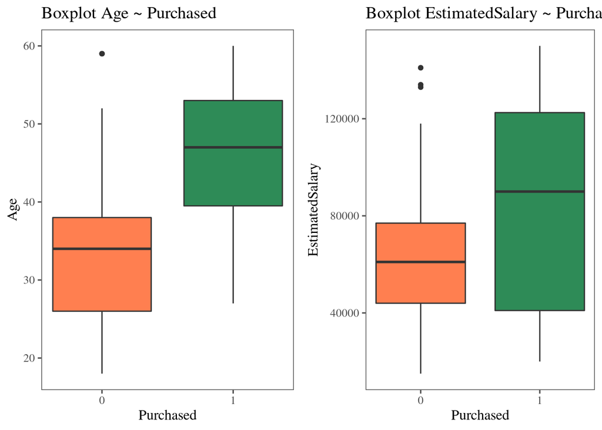

```r
box1 = ggplot(dataset,aes(x=Purchased,group=Purchased,y=Age))+
    geom_boxplot(fill= color_palette)+
    labs(title="Boxplot Age ~ Purchased",
         x="Purchased",
         y="Age")+
    theme_few()+
    theme(axis.title = element_text(),
          text = element_text(family="Serif"))+
    scale_colour_manual(values=color_palette)+
    scale_x_continuous(breaks = c(0,1))

box2 = ggplot(dataset,aes(x=Purchased,group=Purchased,y=EstimatedSalary))+
    geom_boxplot(fill= color_palette)+
    labs(title="Boxplot EstimatedSalary ~ Purchased",
         x="Purchased",
         y="EstimatedSalary")+
    theme_few()+
    theme(axis.title = element_text(),
          text = element_text(family="Serif"))+
    scale_colour_manual(values=color_palette)+
    scale_x_continuous(breaks = c(0,1))

grid.arrange(box1,box2,ncol=2)
```

## AOV of Purchased given Age and EstimatedSalary

```r
summary(aov(EstimatedSalary ~ Purchased, data=dataset))
```

```
##              Df    Sum Sq   Mean Sq F value   Pr(>F)
## Purchased     1 6.082e+10 6.082e+10   60.05 7.77e-14 ***
## Residuals   398 4.031e+11 1.013e+09
## ---
## Signif. codes:  0 '***' 0.001 '**' 0.01 '*' 0.05 '.' 0.1 ' ' 1
```

We see that we have a $p-value$ largely lesser than $0.001$ so we can conclude that the variable `Purchased` is strongly correlated to `EstimatedSalary`

```r
summary(aov(Age ~ Purchased, data=dataset))
```

```
##              Df Sum Sq Mean Sq F value Pr(>F)
## Purchased     1  16988   16988   251.7 <2e-16 ***
## Residuals   398  26858      67
## ---
## Signif. codes:  0 '***' 0.001 '**' 0.01 '*' 0.05 '.' 0.1 ' ' 1
```

Same conclusion for `Age` and `Purchased`

## Correlation between Gender and Purchased ?

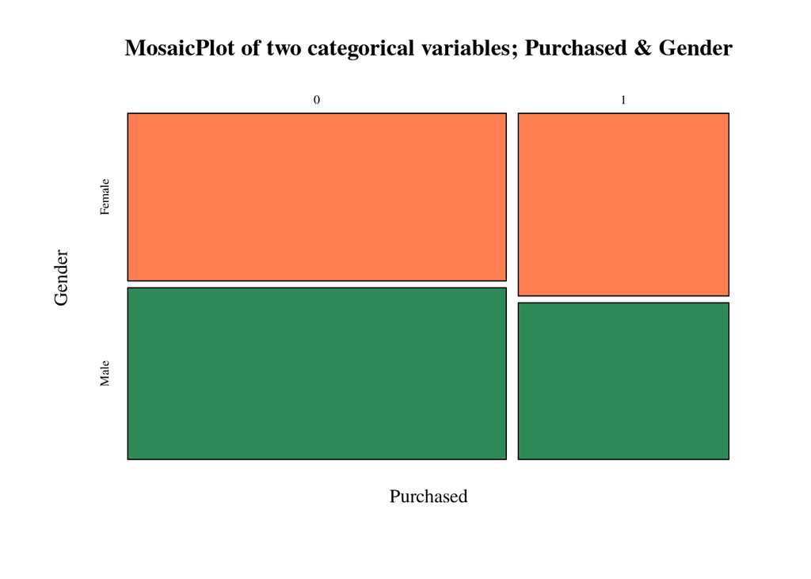

```r
table(dataset$Gender,dataset$Purchased)

par(family = 'serif')
mosaicplot(~ Purchased + Gender,data=dataset,
        main = "MosaicPlot of two categorical variables; Purchased & Gender",
        color = color_palette,lax = 1)
```

[output not shown]

```r
chisq.test(dataset$Purchased,dataset$Gender)
```

```
##
##  Pearson's Chi-squared test with Yates' continuity correction
##
## data:  dataset$Purchased and dataset$Gender
## X-squared = 0.55509, df = 1, p-value = 0.4562
```

## Spliting the data between testing and training

```r
dataset = dataset[3:5]
str(dataset)
```

```
## 'data.frame':    400 obs. of  3 variables:
##  $ Age            : num  19 35 26 27 19 27 27 32 25 35 ...
##  $ EstimatedSalary: num  19000 20000 43000 57000 76000 58000 84000 150000 33000 65000 ...
##  $ Purchased      : int  0 0 0 0 0 0 0 1 0 0 ...
```

```r
set.seed(703521)
split = sample.split(dataset$Purchased,SplitRatio = 0.75)
training_set = subset(dataset,split == TRUE)
test_set = subset(dataset,split == FALSE)
```

## Scaling

```r
training_set[-3] = scale(training_set[-3])
test_set[-3] = scale(test_set[-3])
```

## Building the model

```r
classifier.logreg = glm(Purchased ~ Age + EstimatedSalary, family = binomial,data = training_set)
classifier.logreg
```

```
##
## Call:  glm(formula = Purchased ~ Age + EstimatedSalary, family = binomial,
##     data = training_set)
##
## Coefficients:
##     (Intercept)              Age  EstimatedSalary
##          -1.140            2.513            1.135
##
## Degrees of Freedom: 299 Total (i.e. Null);  297 Residual
## Null Deviance:       390.9
## Residual Deviance: 206.6     AIC: 212.6
```

```r
summary(classifier.logreg)
```

```
##
## Call:
## glm(formula = Purchased ~ Age + EstimatedSalary, family = binomial,
##     data = training_set)
##
## Deviance Residuals:
##     Min       1Q   Median       3Q      Max
## -2.9475  -0.5410  -0.1524   0.3898   1.9266
##
## Coefficients:
##                 Estimate Std. Error z value Pr(>|z|)
## (Intercept)      -1.1396     0.1955  -5.830 5.54e-09 ***
## Age               2.5133     0.3144   7.993 1.32e-15 ***
## EstimatedSalary   1.1354     0.2124   5.345 9.06e-08 ***
## ---
## Signif. codes:  0 '***' 0.001 '**' 0.01 '*' 0.05 '.' 0.1 ' ' 1
##
## (Dispersion parameter for binomial family taken to be 1)
##
##     Null deviance: 390.89  on 299  degrees of freedom
## Residual deviance: 206.58  on 297  degrees of freedom
## AIC: 212.58
##
## Number of Fisher Scoring iterations: 6
```

## Predict

```r
pred.glm = predict(classifier.logreg, newdata = test_set[,-3],type="response")
pred.glm_0_1 = ifelse(pred.glm >= 0.5, 1,0)
head(pred.glm)
```

```
##           2           3           8           9          10          12
## 0.033332337 0.007283443 0.496096987 0.004136625 0.125137070 0.009657580
```

```r
head(pred.glm_0_1)
```

```
##  2  3  8  9 10 12
##  0  0  0  0  0  0
```

## Confusion matrix

```r
cm = table(test_set[,3],pred.glm_0_1)
cm
```

```
##    pred.glm_0_1
##      0  1
##   0 56  8
##   1 10 26
```

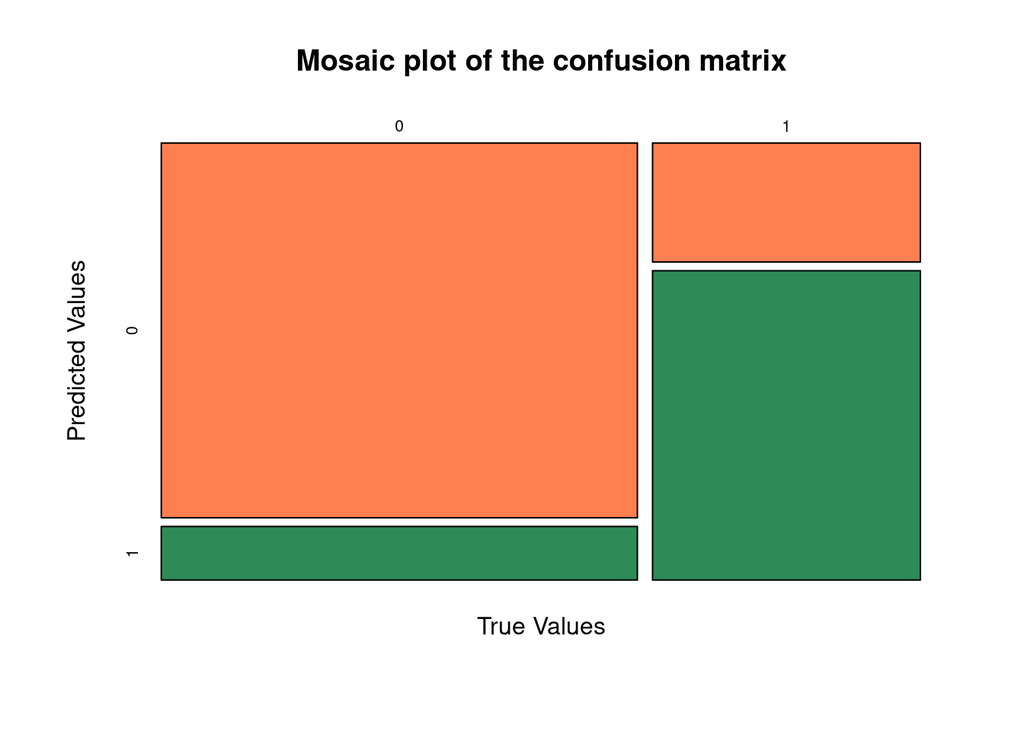

```r
mosaicplot(cm,
           col=color_palette,
           main="Mosaic plot of the confusion matrix",
           xlab="True Values",
           ylab="Predicted Values"
)
```

## ROC

```r
require(ROCR)
score = prediction(pred.glm,test_set[,3])
performance(score,"auc")
```

```
## A performance instance
##   'Area under the ROC curve'
```

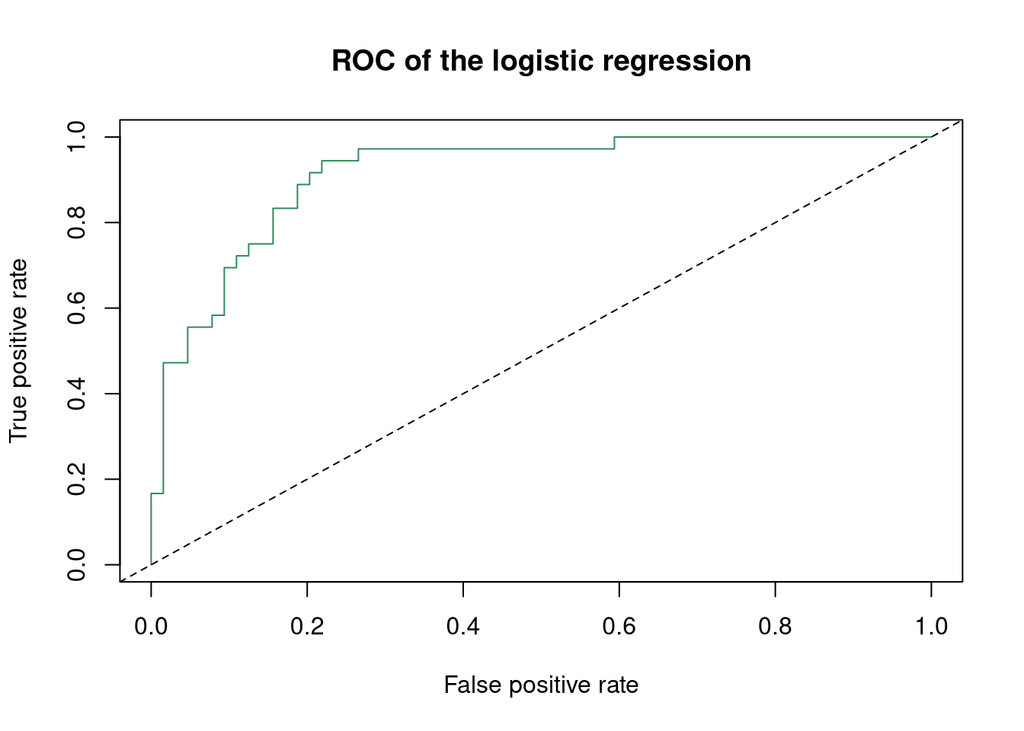

```r
plot(performance(score,"tpr","fpr"),col="seagreen",main="ROC of the logistic regression")
abline(0,1,lty=8)
```

# Decision Boundary of Logistic Regression

## Predicted values

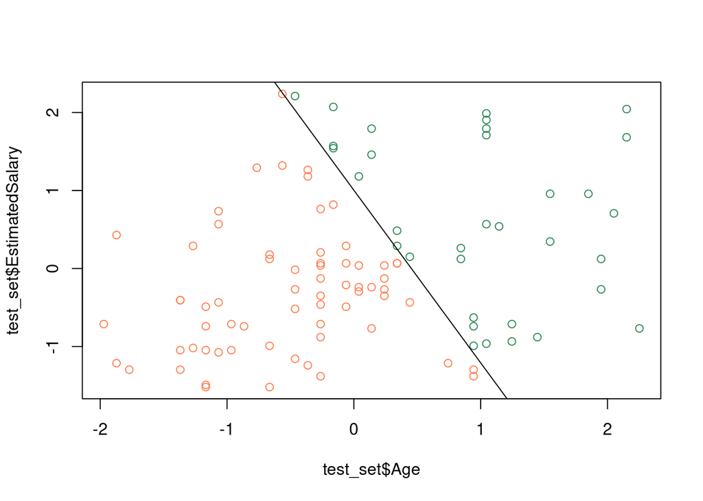

```r
coeff = classifier.logreg$coefficients
beta_0 = unname(coeff[1])
beta_1 = unname(coeff[2])
beta_2 = unname(coeff[3])
intercept = -(beta_0/beta_2)
slope = -(beta_1/beta_2)
color = ifelse(pred.glm_0_1==1,"seagreen","coral")
plot(test_set$Age,test_set$EstimatedSalary,col=color)
abline(intercept,slope)
```

## True values

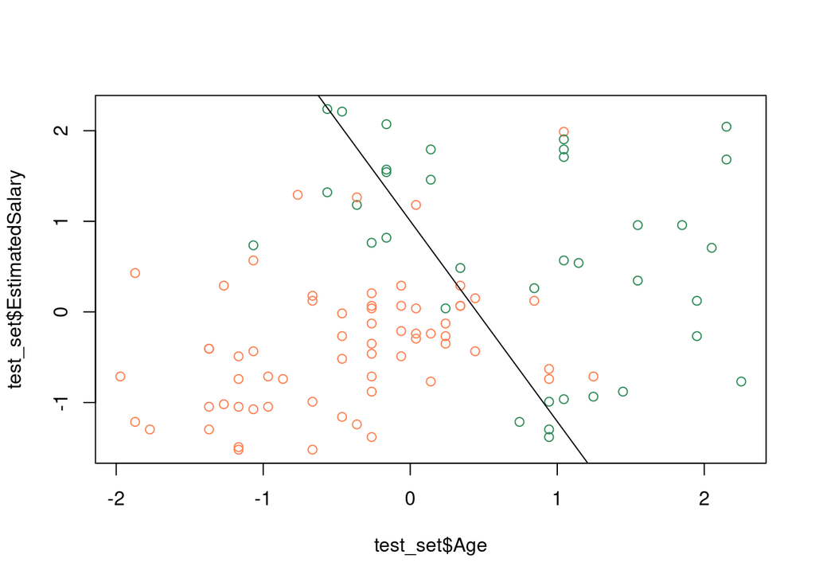

```r
color = ifelse(test_set$Purchased>=0.5,"seagreen","coral")
plot(test_set$Age,test_set$EstimatedSalary,col=color)
abline(intercept,slope)
```

The false positive on the graph are the orange point above the line. We count 8 points which correspond with the value in the confusion matrix.

# Linear Discriminant Analysis (LDA)

## Question 5

```r
library(MASS)
classifier.lda = lda(Purchased ~ Age+EstimatedSalary,data=training_set)
```

## Question 6

```r
classifier.lda
```

```
## Call:
## lda(Purchased ~ Age + EstimatedSalary, data = training_set)
##
## Prior probabilities of groups:
##         0         1
## 0.6433333 0.3566667
##
## Group means:
##          Age EstimatedSalary
## 0 -0.4720458      -0.2369546
## 1  0.8514471       0.4274041
##
## Coefficients of linear discriminants:
##                       LD1
## Age             1.2140365
## EstimatedSalary 0.4992689
```

The prior probabilities part tells us the probability of a random sample being part of a certain group. Here we have:

$$\begin{array}{ll}
p(0) = 0.64\ &(Not\ purchased)\\
p(1) = 0.36\ &(Purchased)
\end{array}$$

The group means part tells us the mean of a feature of a particular group. Here we have:

|  | Age | EstimatedSalary |
| --- | --- | --- |
| 0 | -0.4720458 | -0.2369546 |
| 1 | 0.8514471 | 0.4274041 |

## Question 7

```r
pred.lda = predict(classifier.lda,newdata = test_set[,-3],type="response")
str(pred.lda)
```

```
## List of 3
##  $ class    : Factor w/ 2 levels "0","1": 1 1 1 1 1 1 1 1 1 1 ...
##  $ posterior: num [1:100, 1:2] 0.956 0.99 0.572 0.994 0.866 ...
##   ..- attr(*, "dimnames")=List of 2
##   .. ..$ : chr [1:100] "2" "3" "8" "9" ...
##   .. ..$ : chr [1:2] "0" "1"
##  $ x        : num [1:100, 1] -1.008 -1.787 0.433 -2.048 -0.383 ...
##   ..- attr(*, "dimnames")=List of 2
##   .. ..$ : chr [1:100] "2" "3" "8" "9" ...
##   .. ..$ : chr "LD1"
```

## Question 8

```r
cm.lda = table(test_set[,3],pred.lda$class)
cm.lda
```

```
##
##      0  1
##   0 57  7
##   1 12 24
```

### Accuracy comparison

```r
accuracy = function(cm){
    return ((cm[1]+cm[4])/sum(cm))
}
accuracy_logreg = accuracy(cm)
accuracy_lda = accuracy(cm.lda)
accuracy_logreg
```

```
## [1] 0.82
```

```r
accuracy_lda
```

```
## [1] 0.81
```

We see that we have a better accuracy with the logistic regression than with the linear discrimiant analysis.

## Question 9

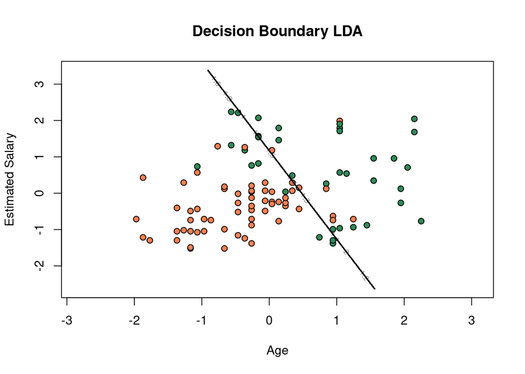

```r
X1 = seq(min(training_set[,1]) - 1, max(training_set[,1]) + 1,by = 0.01)
X2 = seq(min(training_set[,2]) - 1, max(training_set[,2]) + 1,by = 0.01)
grid_set = expand.grid(X1,X2)

colnames(grid_set) = c('Age','EstimatedSalary')

plot(test_set[,1:2],
     main = 'Decision Boundary LDA',
     xlab = 'Age', ylab = 'Estimated Salary',
     xlim = range(X1), ylim = range(X2)
)


points(test_set[1:2], pch = 21, bg = ifelse(test_set[,3] == 1, 'seagreen','coral'))


pred_grid = predict(classifier.lda,newdata=grid_set)$class

contour(X1,X2, matrix(as.numeric(pred_grid), length(X1), length(X2)),add=TRUE)
```

# LDA from scratch

## Question 10

1. Subset the training set

```r
class0 = subset(training_set,Purchased==0)
class1 = subset(training_set,Purchased==1)
```

2. Computation of $\pi_0$ and $pi_1$

```r
N_0 = nrow(class0)
N_1 = nrow(class1)
N = nrow(training_set)

pi_0 = N_0/N
pi_1 = N_1/N
```

3. Computation of $\mu_0 = \begin{pmatrix}\mu_0(X_1)\\\mu_0(X_2)\end{pmatrix}$ and $\mu_1 = \begin{pmatrix}\mu_1(X_1)\\\mu_1(X_2)\end{pmatrix}$

```r
compute_mean_vector = function(class_){
    return (c(mean(class_$Age),mean(class_$EstimatedSalary)))
}
mu_0 = compute_mean_vector(class0)
mu_1 = compute_mean_vector(class1)
mu_0
```

```
## [1] -0.4720458 -0.2369546
```

```r
mu_1
```

```
## [1] 0.8514471 0.4274041
```

4. Computation of $\Sigma$

```r
compute_big_sigma = function(cov0,cov1,N_0,N_1){
    return ( ( (N_0-1)*cov0 + (N_1-1)*cov1 )/(N_0+N_1-2) )
}
cov0 = cov(class0[c(1,2)])
cov1 = cov(class1[c(1,2)])
big_sigma = compute_big_sigma(cov0,cov1,N_0,N_1)
```

5. Computaiton of the discriminant scores

```r
compute_discriminant_score = function(x,cov_matrix,mean_matrix,pi_vector){
    return (t(x)%*%solve(cov_matrix)%*%mean_matrix-(1/2)*sum(t(mean_matrix)%*%solve(cov_matrix)%*%mean_matrix)+log(pi_vector,base=exp(1)))
}

classify = function(x,cov_matrix,mean_matrix,pi_vector){
    dsmt_0 = compute_discriminant_score(x,cov_matrix,mean_matrix[[1]],pi_vector[[1]])
    dsmt_1 = compute_discriminant_score(x,cov_matrix,mean_matrix[[2]],pi_vector[[2]])
    return (ifelse(dsmt_0 > dsmt_1,0,1))
}

classify(c(1,1.5),big_sigma,list(mu_0,mu_1),list(pi_0,pi_1))
```

```
##      [,1]
## [1,]    1
```

```r
pred.lda_scratch = apply(test_set[1:2],1,function(x) classify(x,big_sigma,list(mu_0,mu_1),list(pi_0,pi_1)))

table(test_set$Purchased,pred.lda$class)
```

```
##
##      0  1
##   0 57  7
##   1 12 24
```

# Quadratic Discriminant Analysis (QDA)

## Question 11

```r
classifier.qda = qda(Purchased~., data = training_set)
```

## Question 12

```r
pred.qda = predict(classifier.qda,newdata = test_set[1:2],type="response")
cm.qda = table(test_set$Purchased,pred.qda$class)
```

```r
accuracy_qda = accuracy(cm.qda)
accuracy_lda
```

```
## [1] 0.81
```

```r
accuracy_qda
```

```
## [1] 0.87
```

We see that we have a better accuracy with the quadratic model than with linear one.

## Question 13

[figure not shown]

```r
plot(test_set[,1:2],
     main = 'Decision Boundary LDA',
     xlab = 'Age', ylab = 'Estimated Salary',
     xlim = range(X1), ylim = range(X2)
)

points(test_set[1:2], pch = 21, bg = ifelse(test_set[,3] == 1, 'seagreen','coral'))


pred_grid = predict(classifier.qda,newdata=grid_set)$class

contour(X1,X2, matrix(as.numeric(pred_grid), length(X1), length(X2)),add=TRUE)
```

# Comparison

## Question 14

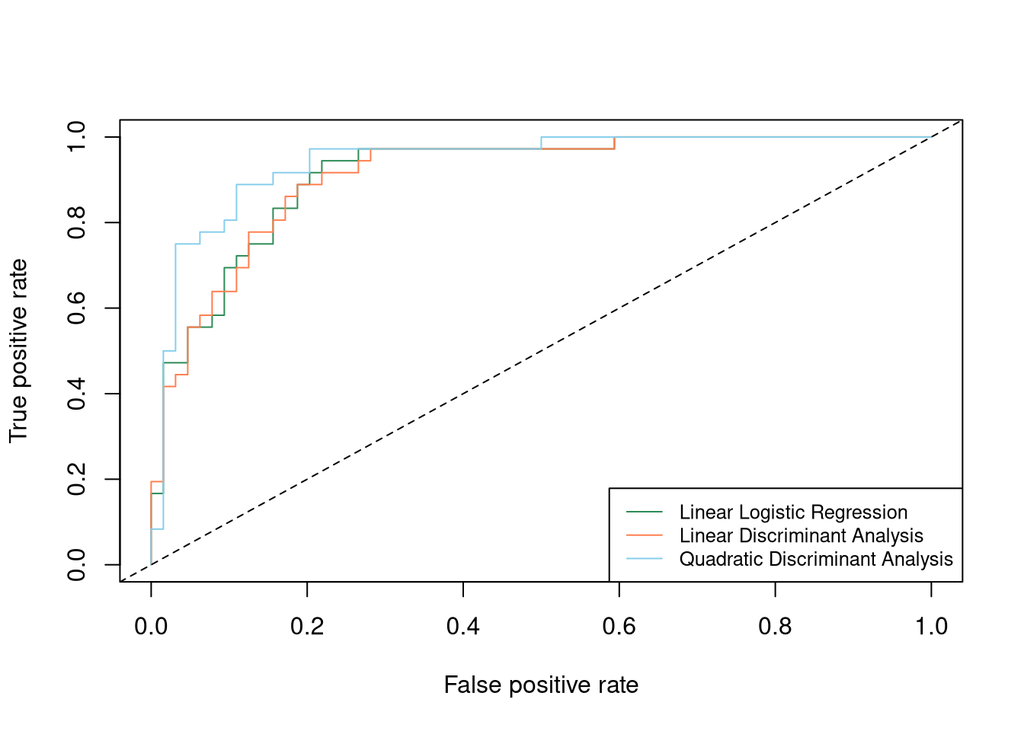

```r
require(ROCR)
score_glm = prediction(pred.glm,test_set[,3])
score_lda = prediction(pred.lda$posterior[,2],test_set[,3])
score_qda = prediction(pred.qda$posterior[,2],test_set[,3])
x_lda = performance(score_lda,"tpr","fpr")@x.values[[1]]
y_lda = performance(score_lda,"tpr","fpr")@y.values[[1]]

x_qda = performance(score_qda,"tpr","fpr")@x.values[[1]]
y_qda = performance(score_qda,"tpr","fpr")@y.values[[1]]

plot(performance(score_glm,"tpr","fpr"),col="seagreen")
legend(x="bottomright",
       legend=c("Linear Logistic Regression",
                  "Linear Discriminant Analysis",
                  "Quadratic Discriminant Analysis"
                  ),
       col=c("seagreen","coral","skyblue"),
       cex=0.8,
       lty=1
)
lines(x_lda,y_lda,col="coral")
lines(x_qda,y_qda,col="skyblue")
abline(0,1,lty=8)
```